# _demo_tmp

```python
import pandas as pd
import numpy as np

#Loading data
data = pd.read_csv("dataset.csv")
#Checking the data columns and their Dtypes
data.info()
```

```
<class 'pandas.core.frame.DataFrame'>
RangeIndex: 73141 entries, 0 to 73140
Data columns (total 15 columns):
 #   Column                Non-Null Count  Dtype
---  ------                --------------  -----
 0   user_id               73141 non-null  object
 1   platform              73141 non-null  object
 2   variant               73141 non-null  object
 3   install_timestamp     73141 non-null  object
 4   country_type          73141 non-null  object
 5   session_timestamp     73136 non-null  object
 6   icon_shop_opens       73141 non-null  int64
 7   inter_shop_opens      73141 non-null  int64
 8   icon_cash_purchases   73141 non-null  int64
 9   inter_cash_purchases  73141 non-null  int64
 10  icon_revenue_usd      73141 non-null  int64
 11  inter_revenue_usd     73141 non-null  int64
 12  session_length        73141 non-null  int64
 13  rvs_watched           73141 non-null  int64
 14  levels_played         73141 non-null  int64
dtypes: int64(9), object(6)
memory usage: 8.4+ MB
```

```python
#Preprocessing data
#I want to calculate Cohort day in this reason I should change install_timestamp
# and session_timestamp data from object to datetime format
data["install_timestamp"] = pd.to_datetime( pd.to_datetime(data["install_timestamp"],
                                                           format="%Y-%m-%d %H:%M:%S").dt.strftime("%d/%m/%Y %H:%M"),
                                           format="%d/%m/%Y %H:%M" )
data["session_timestamp"] = pd.to_datetime( pd.to_datetime(data["session_timestamp"], format="%d/%m/%Y %H:%M") )


data['cohort_day'] = (data['session_timestamp'] - data['install_timestamp']) / np.timedelta64(1, 'D')
data['cohort_day'] = data['cohort_day'].fillna(0).astype(int)
data.info()
```

```
<class 'pandas.core.frame.DataFrame'>
RangeIndex: 73141 entries, 0 to 73140
Data columns (total 16 columns):
 #   Column                Non-Null Count  Dtype
---  ------                --------------  -----
 0   user_id               73141 non-null  object
 1   platform              73141 non-null  object
 2   variant               73141 non-null  object
 3   install_timestamp     73141 non-null  datetime64[ns]
 4   country_type          73141 non-null  object
 5   session_timestamp     73136 non-null  datetime64[ns]
 6   icon_shop_opens       73141 non-null  int64
 7   inter_shop_opens      73141 non-null  int64
 8   icon_cash_purchases   73141 non-null  int64
 9   inter_cash_purchases  73141 non-null  int64
 10  icon_revenue_usd      73141 non-null  int64
 11  inter_revenue_usd     73141 non-null  int64
 12  session_length        73141 non-null  int64
 13  rvs_watched           73141 non-null  int64
 14  levels_played         73141 non-null  int64
 15  cohort_day            73141 non-null  int32
dtypes: datetime64[ns](2), int32(1), int64(9), object(4)
memory usage: 8.6+ MB
```

```python
#I sorted values because of I need to be sure all user_id's sorted
data = data.sort_values(by=["country_type","platform","variant","user_id"]).reset_index(drop=True)
data.head(10)
```

|  | user_id | platform | variant | install_timestamp | country_type | session_timestamp | icon_shop_opens | inter_shop_opens | icon_cash_purchases | inter_cash_purchases | icon_revenue_usd | inter_revenue_usd | session_length | rvs_watched | levels_played | cohort_day |
| --- | --- | --- | --- | --- | --- | --- | --- | --- | --- | --- | --- | --- | --- | --- | --- | --- |
| 0 | 00aQHvrQt3 | android | Control | 2023-01-11 02:36:00 | Non-US | 2023-01-11 02:36:00 | 0 | 0 | 0 | 0 | 0 | 0 | 38 | 14 | 0 | 0 |
| 1 | 00aQHvrQt3 | android | Control | 2023-01-11 02:36:00 | Non-US | 2023-01-14 07:02:00 | 0 | 0 | 0 | 0 | 0 | 0 | 50 | 7 | 5 | 3 |
| 2 | 00aQHvrQt3 | android | Control | 2023-01-11 02:36:00 | Non-US | 2023-01-12 18:43:00 | 0 | 0 | 0 | 0 | 0 | 0 | 25 | 10 | 14 | 1 |
| 3 | 00aQHvrQt3 | android | Control | 2023-01-11 02:36:00 | Non-US | 2023-01-12 21:25:00 | 0 | 0 | 0 | 0 | 0 | 0 | 31 | 21 | 7 | 1 |
| 4 | 00aQHvrQt3 | android | Control | 2023-01-11 02:36:00 | Non-US | 2023-01-18 16:42:00 | 0 | 0 | 0 | 0 | 0 | 0 | 16 | 12 | 16 | 7 |
| 5 | 01k26ICbpj | android | Control | 2023-01-06 20:42:00 | Non-US | 2023-01-06 20:42:00 | 0 | 3 | 0 | 0 | 0 | 0 | 4 | 15 | 19 | 0 |
| 6 | 01k26ICbpj | android | Control | 2023-01-06 20:42:00 | Non-US | 2023-01-07 07:15:00 | 0 | 0 | 0 | 0 | 0 | 0 | 27 | 15 | 25 | 0 |
| 7 | 01k26ICbpj | android | Control | 2023-01-06 20:42:00 | Non-US | 2023-01-10 11:54:00 | 0 | 0 | 0 | 0 | 0 | 0 | 5 | 12 | 5 | 3 |
| 8 | 02qCzXTbcJ | android | Control | 2023-01-01 18:29:00 | Non-US | 2023-01-01 18:29:00 | 0 | 0 | 0 | 0 | 0 | 0 | 10 | 14 | 3 | 0 |
| 9 | 02qCzXTbcJ | android | Control | 2023-01-01 18:29:00 | Non-US | 2023-01-05 21:20:00 | 0 | 0 | 0 | 0 | 0 | 0 | 41 | 17 | 15 | 4 |

```python
# Set the display format for floating-point numbers
# This line specifies that floating-point numbers should be displayed with two decimal places
pd.options.display.float_format = '{:,.2f}'.format

# Set the display option to show all columns
# This line sets the display option to show all columns in the DataFrame
pd.set_option('display.max_columns', None)


# Generate descriptive statistics for the data
# This line generates descriptive statistics for the data, such as count, mean, standard deviation, minimum, and maximum values for each column
data.describe()
```

|  | icon_shop_opens | inter_shop_opens | icon_cash_purchases | inter_cash_purchases | icon_revenue_usd | inter_revenue_usd | session_length | rvs_watched | levels_played | cohort_day |
| --- | --- | --- | --- | --- | --- | --- | --- | --- | --- | --- |
| count | 73,141.00 | 73,141.00 | 73,141.00 | 73,141.00 | 73,141.00 | 73,141.00 | 73,141.00 | 73,141.00 | 73,141.00 | 73,141.00 |
| mean | 0.12 | 0.14 | 0.04 | 0.09 | 0.17 | 0.21 | 29.69 | 12.75 | 15.48 | 2.14 |
| std | 0.52 | 0.56 | 0.37 | 0.76 | 1.56 | 1.77 | 17.04 | 7.81 | 9.75 | 2.79 |
| min | 0.00 | 0.00 | 0.00 | 0.00 | 0.00 | 0.00 | 1.00 | 0.00 | 0.00 | 0.00 |
| 25% | 0.00 | 0.00 | 0.00 | 0.00 | 0.00 | 0.00 | 17.00 | 7.00 | 8.00 | 0.00 |
| 50% | 0.00 | 0.00 | 0.00 | 0.00 | 0.00 | 0.00 | 27.00 | 12.00 | 14.00 | 1.00 |
| 75% | 0.00 | 0.00 | 0.00 | 0.00 | 0.00 | 0.00 | 40.00 | 17.00 | 21.00 | 3.00 |
| max | 5.00 | 5.00 | 7.00 | 14.00 | 34.00 | 34.00 | 103.00 | 50.00 | 61.00 | 20.00 |

```python
# Generate aggregated metrics
# I make a copy from data because I don't want to loose all data while trying to solve question.
# If I loose the data I need to restart the kernel
new_df = data.copy()
new_df["user_id_x"] = new_df["user_id"]
new_df = new_df.groupby(by=["user_id","platform","variant","country_type"
                            ], as_index=False).agg({"user_id":"nunique", "user_id_x":"count", "cohort_day":"max", "icon_shop_opens":"sum",
                                                  "icon_cash_purchases":"sum", "icon_revenue_usd":"sum",
                                                   "inter_shop_opens":"sum", "inter_cash_purchases":"sum",
                                                   "inter_revenue_usd":"sum", "session_length":"sum",
                                                   "rvs_watched":"sum", "levels_played":"sum"})
# Rename columns for clarity

new_df.rename({"user_id":"DAU", "user_id_x":"session_count"}, axis=1, inplace=True)


# Subset data for analysis

df_android_nonus_control = new_df[(new_df["platform"] == "android") &
                                   (new_df["country_type"] == "Non-US") &
                                   (new_df["variant"] == "Control")]
df_android_nonus_newshopicon = new_df[(new_df["platform"] == "android") &
                                   (new_df["country_type"] == "Non-US") &
                                   (new_df["variant"] == "New Shop Icon")]

df_android_us_control = new_df[(new_df["platform"] == "android") &
                                   (new_df["country_type"] == "US") &
                                   (new_df["variant"] == "Control")]
df_android_us_newshopicon = new_df[(new_df["platform"] == "android") &
                                   (new_df["country_type"] == "US") &
                                   (new_df["variant"] == "New Shop Icon")]

df_ios_nonus_control = new_df[(new_df["platform"] == "ios") &
                                   (new_df["country_type"] == "Non-US") &
                                   (new_df["variant"] == "Control")]
df_ios_nonus_newshopicon = new_df[(new_df["platform"] == "ios") &
                                   (new_df["country_type"] == "Non-US") &
                                   (new_df["variant"] == "New Shop Icon")]

df_ios_us_control = new_df[(new_df["platform"] == "ios") &
                                   (new_df["country_type"] == "US") &
                                   (new_df["variant"] == "Control")]
df_ios_us_newshopicon = new_df[(new_df["platform"] == "ios") &
                                   (new_df["country_type"] == "US") &
                                   (new_df["variant"] == "New Shop Icon")]

new_df.reset_index(drop=True, inplace=True)
new_df
```

|  | platform | variant | country_type | DAU | session_count | cohort_day | icon_shop_opens | icon_cash_purchases | icon_revenue_usd | inter_shop_opens | inter_cash_purchases | inter_revenue_usd | session_length | rvs_watched | levels_played |
| --- | --- | --- | --- | --- | --- | --- | --- | --- | --- | --- | --- | --- | --- | --- | --- |
| 0 | ios | New Shop Icon | Non-US | 1 | 3 | 3 | 2 | 0 | 0 | 0 | 0 | 0 | 126 | 69 | 76 |
| 1 | ios | Control | Non-US | 1 | 2 | 4 | 0 | 0 | 0 | 0 | 0 | 0 | 72 | 22 | 60 |
| 2 | android | Control | Non-US | 1 | 5 | 7 | 0 | 0 | 0 | 0 | 0 | 0 | 160 | 64 | 42 |
| 3 | ios | Control | Non-US | 1 | 2 | 10 | 0 | 0 | 0 | 4 | 3 | 8 | 84 | 61 | 30 |
| 4 | android | Control | Non-US | 1 | 3 | 3 | 0 | 0 | 0 | 3 | 0 | 0 | 36 | 42 | 49 |
| ... | ... | ... | ... | ... | ... | ... | ... | ... | ... | ... | ... | ... | ... | ... | ... |
| 19995 | android | New Shop Icon | Non-US | 1 | 4 | 5 | 1 | 0 | 0 | 0 | 0 | 0 | 90 | 34 | 74 |
| 19996 | ios | New Shop Icon | US | 1 | 4 | 1 | 0 | 0 | 0 | 0 | 0 | 0 | 120 | 30 | 127 |
| 19997 | ios | New Shop Icon | Non-US | 1 | 4 | 1 | 0 | 0 | 0 | 0 | 0 | 0 | 122 | 50 | 65 |
| 19998 | android | Control | Non-US | 1 | 4 | 7 | 2 | 0 | 0 | 1 | 3 | 10 | 99 | 62 | 33 |
| 19999 | android | New Shop Icon | Non-US | 1 | 1 | 0 | 0 | 0 | 0 | 0 | 0 | 0 | 3 | 9 | 26 |

20000 rows × 15 columns

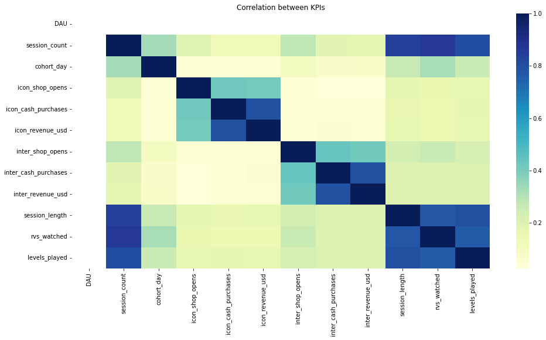

```python
import seaborn as sns
import matplotlib.pyplot as plt
corr = new_df.corr()

# Create a heatmap to visualize the correlation matrix
# This line creates a heatmap using seaborn to visualize the correlation matrix, with a color map of YlGnBu
plt.figure(figsize=(16,8))
sns.heatmap(corr, cmap="YlGnBu")

# Set the title of the heatmap
# This line sets the title of the heatmap to "Correlation between KPIs"
plt.title('Correlation between KPIs')

# Display the heatmap
# This line displays the heatmap
plt.show()
```

```python
# Descriptive statistics
df_android_nonus_control.describe()
```

|  | DAU | session_count | cohort_day | icon_shop_opens | icon_cash_purchases | icon_revenue_usd | inter_shop_opens | inter_cash_purchases | inter_revenue_usd | session_length | rvs_watched | levels_played |
| --- | --- | --- | --- | --- | --- | --- | --- | --- | --- | --- | --- | --- |
| count | 4,683.00 | 4,683.00 | 4,683.00 | 4,683.00 | 4,683.00 | 4,683.00 | 4,683.00 | 4,683.00 | 4,683.00 | 4,683.00 | 4,683.00 | 4,683.00 |
| mean | 1.00 | 4.21 | 4.78 | 0.38 | 0.05 | 0.16 | 0.65 | 0.14 | 0.27 | 98.50 | 49.78 | 47.09 |
| std | 0.00 | 2.11 | 3.36 | 0.92 | 0.40 | 1.42 | 1.23 | 0.95 | 1.83 | 55.70 | 28.25 | 27.12 |
| min | 1.00 | 1.00 | 0.00 | 0.00 | 0.00 | 0.00 | 0.00 | 0.00 | 0.00 | 1.00 | 1.00 | 0.00 |
| 25% | 1.00 | 3.00 | 2.00 | 0.00 | 0.00 | 0.00 | 0.00 | 0.00 | 0.00 | 55.00 | 28.00 | 26.00 |
| 50% | 1.00 | 4.00 | 4.00 | 0.00 | 0.00 | 0.00 | 0.00 | 0.00 | 0.00 | 91.00 | 46.00 | 43.00 |
| 75% | 1.00 | 6.00 | 7.00 | 0.00 | 0.00 | 0.00 | 1.00 | 0.00 | 0.00 | 134.00 | 67.00 | 64.00 |
| max | 1.00 | 12.00 | 18.00 | 8.00 | 6.00 | 27.00 | 11.00 | 12.00 | 24.00 | 309.00 | 176.00 | 164.00 |

```python
# Descriptive statistics
df_android_nonus_newshopicon.describe()
```

|  | DAU | session_count | cohort_day | icon_shop_opens | icon_cash_purchases | icon_revenue_usd | inter_shop_opens | inter_cash_purchases | inter_revenue_usd | session_length | rvs_watched | levels_played |
| --- | --- | --- | --- | --- | --- | --- | --- | --- | --- | --- | --- | --- |
| count | 5,083.00 | 5,083.00 | 5,083.00 | 5,083.00 | 5,083.00 | 5,083.00 | 5,083.00 | 5,083.00 | 5,083.00 | 5,083.00 | 5,083.00 | 5,083.00 |
| mean | 1.00 | 2.79 | 2.47 | 0.38 | 0.04 | 0.16 | 0.32 | 0.08 | 0.15 | 75.53 | 28.71 | 36.65 |
| std | 0.00 | 1.34 | 2.16 | 0.99 | 0.39 | 1.48 | 0.91 | 0.67 | 1.33 | 43.12 | 17.38 | 21.58 |
| min | 1.00 | 1.00 | 0.00 | 0.00 | 0.00 | 0.00 | 0.00 | 0.00 | 0.00 | 1.00 | 0.00 | 0.00 |
| 25% | 1.00 | 2.00 | 1.00 | 0.00 | 0.00 | 0.00 | 0.00 | 0.00 | 0.00 | 43.00 | 16.00 | 20.00 |
| 50% | 1.00 | 3.00 | 2.00 | 0.00 | 0.00 | 0.00 | 0.00 | 0.00 | 0.00 | 69.00 | 26.00 | 33.00 |
| 75% | 1.00 | 4.00 | 4.00 | 0.00 | 0.00 | 0.00 | 0.00 | 0.00 | 0.00 | 102.00 | 39.00 | 50.00 |
| max | 1.00 | 8.00 | 11.00 | 11.00 | 6.00 | 27.00 | 8.00 | 11.00 | 24.00 | 296.00 | 117.00 | 155.00 |

```
No artists with labels found to put in legend.  Note that artists whose label start with an underscore are ignored when legend() is called with no argument.
```

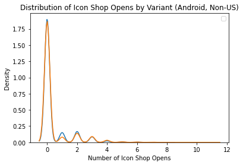

```python
# Plot the distribution of 'icon_shop_opens' for each variant
sns.kdeplot(df_android_nonus_control['icon_shop_opens'])
sns.kdeplot(df_android_nonus_newshopicon['icon_shop_opens'])

plt.xlabel('Number of Icon Shop Opens')
plt.ylabel('Density')
plt.title('Distribution of Icon Shop Opens by Variant (Android, Non-US)')
plt.legend()
plt.show()
```

```python
import numpy as np
# Calculate CTR and standard error

control_ctr = sum(df_android_nonus_control['icon_shop_opens']) / len(df_android_nonus_control)
variant_ctr = sum(df_android_nonus_newshopicon['icon_shop_opens']) / len(df_android_nonus_newshopicon)

print("control_ctr: ", control_ctr)
print("variant_ctr: ", variant_ctr)

import math

control_size = len(df_android_nonus_control)
variant_size = len(df_android_nonus_newshopicon)

control_se = math.sqrt(control_ctr * (1 - control_ctr) / control_size)
variant_se = math.sqrt(variant_ctr * (1 - variant_ctr) / variant_size)

print("control_se: ", control_se)
print("variant_se: ", variant_se)


import statsmodels.api as sm

# Perform two-sample z-test
z_stat, p_value = sm.stats.proportions_ztest([control_ctr * control_size, variant_ctr * variant_size], [control_size, variant_size])

print("z_stat:", z_stat)
print("p_value", p_value)
# Set the significance level (alpha) and make a decision based on the p-value
alpha = 0.05

if p_value < alpha:
    print("Result: Reject the null hypothesis. There is a significant difference in shop button CTR between the groups.")
else:
    print("Result: Fail to reject the null hypothesis. There is no significant difference in shop button CTR between the groups.")
```

```
control_ctr:  0.3843689942344651
variant_ctr:  0.3808774345858745
control_se:  0.007108407838003101
variant_se:  0.006811156879590583
z_stat: 0.3546809553961692
p_value 0.7228286199445458
Result: Fail to reject the null hypothesis. There is no significant difference in shop button CTR between the groups.
```

```
WARNING (theano.tensor.blas): Using NumPy C-API based implementation for BLAS functions.
```

```
control_clicks:  1800
control_views:  4683
variant_clicks:  1936
variant_views:  5083
```

100.00% [12000/12000 00:09<00:00 Sampling 4 chains, 0 divergences]

```
Sampling 4 chains for 1_000 tune and 2_000 draw iterations (4_000 + 8_000 draws total) took 32 seconds.
Got error No model on context stack. trying to find log_likelihood in translation.
Got error No model on context stack. trying to find log_likelihood in translation.
Got error No model on context stack. trying to find log_likelihood in translation.
```

```
Probability of variant rate > control rate: 0.37125
Probability of variant rate < control rate: 0.62875
```

```
       mean   sd  hdi_3%  hdi_97%  mcse_mean  mcse_sd  ess_bulk  ess_tail  \
delta -0.00 0.01   -0.02     0.02       0.00     0.00  6,924.00  5,648.00

       r_hat
delta   1.00
```

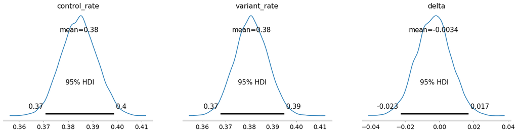

```python
import pymc3 as pm

# Extract observed data

control_clicks = df_android_nonus_control['icon_shop_opens'].sum()
control_views = len(df_android_nonus_control)
variant_clicks = df_android_nonus_newshopicon['icon_shop_opens'].sum()
variant_views = len(df_android_nonus_newshopicon)

print("control_clicks: " , control_clicks)
print("control_views: " , control_views)
print("variant_clicks: " , variant_clicks)
print("variant_views: " , variant_views)

# Define the model
with pm.Model() as model:
    # Prior distributions for the proportions
    control_rate = pm.Beta('control_rate', alpha=1, beta=1)
    variant_rate = pm.Beta('variant_rate', alpha=1, beta=1)

    # Likelihoods
    control_successes = pm.Binomial('control_successes', n=control_views, p=control_rate, observed=control_clicks)
    variant_successes = pm.Binomial('variant_successes', n=variant_views, p=variant_rate, observed=variant_clicks)

    # Difference in proportions
    delta = pm.Deterministic('delta', variant_rate - control_rate)

    # Sampling
    trace = pm.sample(2000, tune=1000)

# Summarize the posterior distribution
pm.summary(trace, hdi_prob=0.95)

# Plot the posterior distribution
pm.plot_posterior(trace, hdi_prob=0.95)

# Make a decision based on the posterior distribution
prob_delta_positive = (trace['delta'] > 0).mean()
prob_delta_negative = (trace['delta'] < 0).mean()
print("Probability of variant rate > control rate:", prob_delta_positive)
print("Probability of variant rate < control rate:", prob_delta_negative)
# Print the summary of the posterior distribution
print(pm.summary(trace, var_names=['delta']))
```

```
No artists with labels found to put in legend.  Note that artists whose label start with an underscore are ignored when legend() is called with no argument.
```

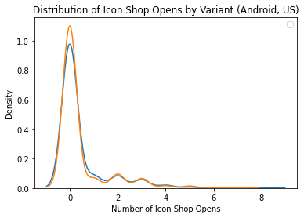

```python
# Plot the distribution of 'icon_shop_opens' for each variant
sns.kdeplot(df_android_us_control["icon_shop_opens"])
sns.kdeplot(df_android_us_newshopicon["icon_shop_opens"])

plt.xlabel('Number of Icon Shop Opens')
plt.ylabel('Density')
plt.title('Distribution of Icon Shop Opens by Variant (Android, US)')
plt.legend()
plt.show()
```

```python
# Descriptive statistics
df_android_us_control.describe()
```

|  | DAU | session_count | cohort_day | icon_shop_opens | icon_cash_purchases | icon_revenue_usd | inter_shop_opens | inter_cash_purchases | inter_revenue_usd | session_length | rvs_watched | levels_played |
| --- | --- | --- | --- | --- | --- | --- | --- | --- | --- | --- | --- | --- |
| count | 370.00 | 370.00 | 370.00 | 370.00 | 370.00 | 370.00 | 370.00 | 370.00 | 370.00 | 370.00 | 370.00 | 370.00 |
| mean | 1.00 | 4.01 | 4.98 | 0.45 | 0.04 | 0.15 | 0.61 | 0.16 | 0.31 | 90.06 | 47.40 | 44.64 |
| std | 0.00 | 2.03 | 3.59 | 1.06 | 0.33 | 1.24 | 1.21 | 1.04 | 2.20 | 53.56 | 28.75 | 26.01 |
| min | 1.00 | 1.00 | 0.00 | 0.00 | 0.00 | 0.00 | 0.00 | 0.00 | 0.00 | 4.00 | 2.00 | 1.00 |
| 25% | 1.00 | 2.00 | 2.00 | 0.00 | 0.00 | 0.00 | 0.00 | 0.00 | 0.00 | 52.25 | 26.00 | 26.00 |
| 50% | 1.00 | 4.00 | 4.00 | 0.00 | 0.00 | 0.00 | 0.00 | 0.00 | 0.00 | 82.00 | 43.50 | 39.00 |
| 75% | 1.00 | 5.00 | 8.00 | 0.00 | 0.00 | 0.00 | 1.00 | 0.00 | 0.00 | 117.75 | 62.00 | 62.00 |
| max | 1.00 | 11.00 | 14.00 | 8.00 | 4.00 | 16.00 | 6.00 | 9.00 | 24.00 | 310.00 | 157.00 | 144.00 |

```python
# Descriptive statistics
df_android_us_newshopicon.describe()
```

|  | DAU | session_count | cohort_day | icon_shop_opens | icon_cash_purchases | icon_revenue_usd | inter_shop_opens | inter_cash_purchases | inter_revenue_usd | session_length | rvs_watched | levels_played |
| --- | --- | --- | --- | --- | --- | --- | --- | --- | --- | --- | --- | --- |
| count | 586.00 | 586.00 | 586.00 | 586.00 | 586.00 | 586.00 | 586.00 | 586.00 | 586.00 | 586.00 | 586.00 | 586.00 |
| mean | 1.00 | 2.77 | 2.46 | 0.44 | 0.03 | 0.15 | 0.30 | 0.03 | 0.10 | 75.31 | 28.26 | 35.68 |
| std | 0.00 | 1.29 | 2.13 | 1.05 | 0.27 | 1.43 | 0.96 | 0.27 | 1.16 | 41.71 | 16.87 | 20.37 |
| min | 1.00 | 1.00 | 0.00 | 0.00 | 0.00 | 0.00 | 0.00 | 0.00 | 0.00 | 3.00 | 0.00 | 0.00 |
| 25% | 1.00 | 2.00 | 1.00 | 0.00 | 0.00 | 0.00 | 0.00 | 0.00 | 0.00 | 43.00 | 16.00 | 20.00 |
| 50% | 1.00 | 3.00 | 2.00 | 0.00 | 0.00 | 0.00 | 0.00 | 0.00 | 0.00 | 71.00 | 25.00 | 33.00 |
| 75% | 1.00 | 4.00 | 4.00 | 0.00 | 0.00 | 0.00 | 0.00 | 0.00 | 0.00 | 100.75 | 38.00 | 48.75 |
| max | 1.00 | 7.00 | 9.00 | 7.00 | 4.00 | 18.00 | 8.00 | 3.00 | 19.00 | 239.00 | 99.00 | 114.00 |

```python
import numpy as np
# Calculate CTR and standard error

control_ctr = sum(df_android_us_control['icon_shop_opens']) / len(df_android_us_control)
variant_ctr = sum(df_android_us_newshopicon['icon_shop_opens']) / len(df_android_us_newshopicon)

print("control_ctr: ", control_ctr)
print("variant_ctr: ", variant_ctr)

import math

control_size = len(df_android_us_control)
variant_size = len(df_android_us_newshopicon)

control_se = math.sqrt(control_ctr * (1 - control_ctr) / control_size)
variant_se = math.sqrt(variant_ctr * (1 - variant_ctr) / variant_size)

print("control_se: ", control_se)
print("variant_se: ", variant_se)


import statsmodels.api as sm

# Perform two-sample z-test
z_stat, p_value = sm.stats.proportions_ztest([control_ctr * control_size, variant_ctr * variant_size], [control_size, variant_size])

print("z_stat:", z_stat)
print("p_value", p_value)
# Set the significance level (alpha) and make a decision based on the p-value
alpha = 0.05

if p_value < alpha:
    print("Result: Reject the null hypothesis. There is a significant difference in shop button CTR between the groups.")
else:
    print("Result: Fail to reject the null hypothesis. There is no significant difference in shop button CTR between the groups.")
```

```
control_ctr:  0.4540540540540541
variant_ctr:  0.44368600682593856
control_se:  0.025883782361304623
variant_se:  0.020523387731582556
z_stat: 0.3140051255773437
p_value 0.7535171458706567
Result: Fail to reject the null hypothesis. There is no significant difference in shop button CTR between the groups.
```

```
control_clicks:  168
control_views:  370
variant_clicks:  260
variant_views:  586
```

100.00% [12000/12000 00:10<00:00 Sampling 4 chains, 0 divergences]

```
Sampling 4 chains for 1_000 tune and 2_000 draw iterations (4_000 + 8_000 draws total) took 34 seconds.
Got error No model on context stack. trying to find log_likelihood in translation.
Got error No model on context stack. trying to find log_likelihood in translation.
Got error No model on context stack. trying to find log_likelihood in translation.
```

```
Probability of variant rate > control rate: 0.3655
Probability of variant rate < control rate: 0.6345
```

```
       mean   sd  hdi_3%  hdi_97%  mcse_mean  mcse_sd  ess_bulk  ess_tail  \
delta -0.01 0.03   -0.07     0.05       0.00     0.00  7,412.00  5,547.00

       r_hat
delta   1.00
```

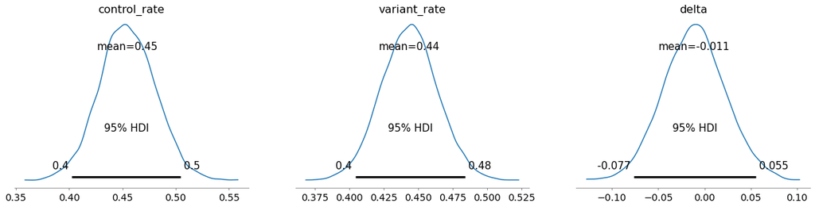

```python
# Observed data

control_clicks = df_android_us_control['icon_shop_opens'].sum()
control_views = len(df_android_us_control)
variant_clicks = df_android_us_newshopicon['icon_shop_opens'].sum()
variant_views = len(df_android_us_newshopicon)

print("control_clicks: " , control_clicks)
print("control_views: " , control_views)
print("variant_clicks: " , variant_clicks)
print("variant_views: " , variant_views)

# Define the model
with pm.Model() as model:
    # Prior distributions for the proportions
    control_rate = pm.Beta('control_rate', alpha=1, beta=1)
    variant_rate = pm.Beta('variant_rate', alpha=1, beta=1)

    # Likelihoods
    control_successes = pm.Binomial('control_successes', n=control_views, p=control_rate, observed=control_clicks)
    variant_successes = pm.Binomial('variant_successes', n=variant_views, p=variant_rate, observed=variant_clicks)

    # Difference in proportions
    delta = pm.Deterministic('delta', variant_rate - control_rate)

    # Sampling
    trace = pm.sample(2000, tune=1000)

# Summarize the posterior distribution
pm.summary(trace, hdi_prob=0.95)

# Plot the posterior distribution
pm.plot_posterior(trace, hdi_prob=0.95)

# Make a decision based on the posterior distribution
prob_delta_positive = (trace['delta'] > 0).mean()
prob_delta_negative = (trace['delta'] < 0).mean()
print("Probability of variant rate > control rate:", prob_delta_positive)
print("Probability of variant rate < control rate:", prob_delta_negative)
# Print the summary of the posterior distribution
print(pm.summary(trace, var_names=['delta']))
```

```
No artists with labels found to put in legend.  Note that artists whose label start with an underscore are ignored when legend() is called with no argument.
```

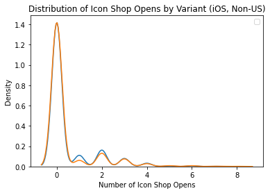

```python
# Plot the distribution of 'icon_shop_opens' for each variant
sns.kdeplot(df_ios_nonus_control["icon_shop_opens"])
sns.kdeplot(df_ios_nonus_newshopicon["icon_shop_opens"])

plt.xlabel('Number of Icon Shop Opens')
plt.ylabel('Density')
plt.title('Distribution of Icon Shop Opens by Variant (iOS, Non-US)')
plt.legend()
plt.show()
```

```python
# Descriptive statistics
df_ios_nonus_control.describe()
```

|  | DAU | session_count | cohort_day | icon_shop_opens | icon_cash_purchases | icon_revenue_usd | inter_shop_opens | inter_cash_purchases | inter_revenue_usd | session_length | rvs_watched | levels_played |
| --- | --- | --- | --- | --- | --- | --- | --- | --- | --- | --- | --- | --- |
| count | 2,616.00 | 2,616.00 | 2,616.00 | 2,616.00 | 2,616.00 | 2,616.00 | 2,616.00 | 2,616.00 | 2,616.00 | 2,616.00 | 2,616.00 | 2,616.00 |
| mean | 1.00 | 4.74 | 5.69 | 0.49 | 0.30 | 1.21 | 0.74 | 0.88 | 2.05 | 153.41 | 72.00 | 83.73 |
| std | 0.00 | 2.39 | 3.80 | 1.06 | 1.03 | 4.29 | 1.31 | 2.39 | 5.60 | 87.10 | 41.25 | 48.23 |
| min | 1.00 | 1.00 | 0.00 | 0.00 | 0.00 | 0.00 | 0.00 | 0.00 | 0.00 | 4.00 | 1.00 | 2.00 |
| 25% | 1.00 | 3.00 | 3.00 | 0.00 | 0.00 | 0.00 | 0.00 | 0.00 | 0.00 | 87.00 | 40.00 | 47.00 |
| 50% | 1.00 | 4.00 | 5.00 | 0.00 | 0.00 | 0.00 | 0.00 | 0.00 | 0.00 | 138.00 | 66.00 | 76.00 |
| 75% | 1.00 | 6.00 | 8.00 | 0.00 | 0.00 | 0.00 | 1.00 | 0.00 | 0.00 | 208.00 | 98.00 | 113.25 |
| max | 1.00 | 13.00 | 20.00 | 7.00 | 11.00 | 41.00 | 10.00 | 22.00 | 41.00 | 538.00 | 229.00 | 296.00 |

```python
# Descriptive statistics
df_ios_nonus_newshopicon.describe()
```

|  | DAU | session_count | cohort_day | icon_shop_opens | icon_cash_purchases | icon_revenue_usd | inter_shop_opens | inter_cash_purchases | inter_revenue_usd | session_length | rvs_watched | levels_played |
| --- | --- | --- | --- | --- | --- | --- | --- | --- | --- | --- | --- | --- |
| count | 2,362.00 | 2,362.00 | 2,362.00 | 2,362.00 | 2,362.00 | 2,362.00 | 2,362.00 | 2,362.00 | 2,362.00 | 2,362.00 | 2,362.00 | 2,362.00 |
| mean | 1.00 | 3.11 | 2.96 | 0.45 | 0.24 | 0.98 | 0.37 | 0.34 | 0.85 | 117.07 | 41.17 | 64.84 |
| std | 0.00 | 1.54 | 2.42 | 1.09 | 0.92 | 3.74 | 0.97 | 1.39 | 3.42 | 66.94 | 25.08 | 38.77 |
| min | 1.00 | 1.00 | 0.00 | 0.00 | 0.00 | 0.00 | 0.00 | 0.00 | 0.00 | 2.00 | 0.00 | 0.00 |
| 25% | 1.00 | 2.00 | 1.00 | 0.00 | 0.00 | 0.00 | 0.00 | 0.00 | 0.00 | 66.00 | 21.00 | 35.00 |
| 50% | 1.00 | 3.00 | 3.00 | 0.00 | 0.00 | 0.00 | 0.00 | 0.00 | 0.00 | 108.00 | 38.00 | 59.00 |
| 75% | 1.00 | 4.00 | 4.00 | 0.00 | 0.00 | 0.00 | 0.00 | 0.00 | 0.00 | 158.00 | 56.00 | 88.00 |
| max | 1.00 | 9.00 | 12.00 | 8.00 | 7.00 | 31.00 | 7.00 | 12.00 | 38.00 | 412.00 | 186.00 | 249.00 |

```python
import numpy as np
# Calculate CTR and standard error

control_ctr = sum(df_ios_nonus_control['icon_shop_opens']) / len(df_ios_nonus_control)
variant_ctr = sum(df_ios_nonus_newshopicon['icon_shop_opens']) / len(df_ios_nonus_newshopicon)

print("control_ctr: ", control_ctr)
print("variant_ctr: ", variant_ctr)

import math

control_size = len(df_ios_nonus_control)
variant_size = len(df_ios_nonus_newshopicon)

control_se = math.sqrt(control_ctr * (1 - control_ctr) / control_size)
variant_se = math.sqrt(variant_ctr * (1 - variant_ctr) / variant_size)

print("control_se: ", control_se)
print("variant_se: ", variant_se)


import statsmodels.api as sm

# Perform two-sample z-test
z_stat, p_value = sm.stats.proportions_ztest([control_ctr * control_size, variant_ctr * variant_size], [control_size, variant_size])

print("z_stat:", z_stat)
print("p_value", p_value)
# Set the significance level (alpha) and make a decision based on the p-value
alpha = 0.05

if p_value < alpha:
    print("Result: Reject the null hypothesis. There is a significant difference in shop button CTR between the groups.")
else:
    print("Result: Fail to reject the null hypothesis. There is no significant difference in shop button CTR between the groups.")
```

```
control_ctr:  0.48623853211009177
variant_ctr:  0.4462320067739204
control_se:  0.009772070253237964
variant_se:  0.01022832072418369
z_stat: 2.8250457217849276
p_value 0.0047273869752067245
Result: Reject the null hypothesis. There is a significant difference in shop button CTR between the groups.
```

```
control_clicks:  1272
control_views:  2616
variant_clicks:  1054
variant_views:  2362
```

100.00% [12000/12000 00:09<00:00 Sampling 4 chains, 0 divergences]

```
Sampling 4 chains for 1_000 tune and 2_000 draw iterations (4_000 + 8_000 draws total) took 32 seconds.
Got error No model on context stack. trying to find log_likelihood in translation.
Got error No model on context stack. trying to find log_likelihood in translation.
Got error No model on context stack. trying to find log_likelihood in translation.
```

```
Probability of variant rate > control rate: 0.0035
Probability of variant rate < control rate: 0.9965
```

```
       mean   sd  hdi_3%  hdi_97%  mcse_mean  mcse_sd  ess_bulk  ess_tail  \
delta -0.04 0.01   -0.07    -0.01       0.00     0.00  6,659.00  5,286.00

       r_hat
delta   1.00
```

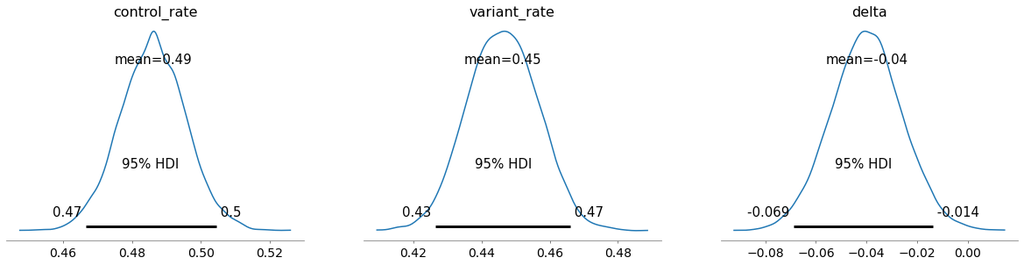

```python
# Observed data

control_clicks = df_ios_nonus_control['icon_shop_opens'].sum()
control_views = len(df_ios_nonus_control)
variant_clicks = df_ios_nonus_newshopicon['icon_shop_opens'].sum()
variant_views = len(df_ios_nonus_newshopicon)

print("control_clicks: " , control_clicks)
print("control_views: " , control_views)
print("variant_clicks: " , variant_clicks)
print("variant_views: " , variant_views)

# Define the model
with pm.Model() as model:
    # Prior distributions for the proportions
    control_rate = pm.Beta('control_rate', alpha=1, beta=1)
    variant_rate = pm.Beta('variant_rate', alpha=1, beta=1)

    # Likelihoods
    control_successes = pm.Binomial('control_successes', n=control_views, p=control_rate, observed=control_clicks)
    variant_successes = pm.Binomial('variant_successes', n=variant_views, p=variant_rate, observed=variant_clicks)

    # Difference in proportions
    delta = pm.Deterministic('delta', variant_rate - control_rate)

    # Sampling
    trace = pm.sample(2000, tune=1000)

# Summarize the posterior distribution
pm.summary(trace, hdi_prob=0.95)

# Plot the posterior distribution
pm.plot_posterior(trace, hdi_prob=0.95)

# Make a decision based on the posterior distribution
prob_delta_positive = (trace['delta'] > 0).mean()
prob_delta_negative = (trace['delta'] < 0).mean()
print("Probability of variant rate > control rate:", prob_delta_positive)
print("Probability of variant rate < control rate:", prob_delta_negative)
# Print the summary of the posterior distribution
print(pm.summary(trace, var_names=['delta']))
```

```
No artists with labels found to put in legend.  Note that artists whose label start with an underscore are ignored when legend() is called with no argument.
```

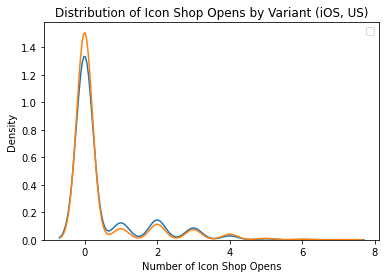

```python
# Plot the distribution of 'icon_shop_opens' for each variant
sns.kdeplot(df_ios_us_control["icon_shop_opens"])
sns.kdeplot(df_ios_us_newshopicon["icon_shop_opens"])

plt.xlabel('Number of Icon Shop Opens')
plt.ylabel('Density')
plt.title('Distribution of Icon Shop Opens by Variant (iOS, US)')
plt.legend()
plt.show()
```

```python
df_ios_us_control.describe()
```

|  | DAU | session_count | cohort_day | icon_shop_opens | icon_cash_purchases | icon_revenue_usd | inter_shop_opens | inter_cash_purchases | inter_revenue_usd | session_length | rvs_watched | levels_played |
| --- | --- | --- | --- | --- | --- | --- | --- | --- | --- | --- | --- | --- |
| count | 1,727.00 | 1,727.00 | 1,727.00 | 1,727.00 | 1,727.00 | 1,727.00 | 1,727.00 | 1,727.00 | 1,727.00 | 1,727.00 | 1,727.00 | 1,727.00 |
| mean | 1.00 | 4.82 | 5.64 | 0.48 | 0.31 | 1.39 | 0.77 | 0.83 | 2.02 | 155.71 | 73.68 | 84.87 |
| std | 0.00 | 2.46 | 3.83 | 1.02 | 1.02 | 4.57 | 1.34 | 2.24 | 5.56 | 90.10 | 41.61 | 49.26 |
| min | 1.00 | 1.00 | 0.00 | 0.00 | 0.00 | 0.00 | 0.00 | 0.00 | 0.00 | 3.00 | 0.00 | 1.00 |
| 25% | 1.00 | 3.00 | 3.00 | 0.00 | 0.00 | 0.00 | 0.00 | 0.00 | 0.00 | 84.00 | 41.00 | 47.00 |
| 50% | 1.00 | 4.00 | 5.00 | 0.00 | 0.00 | 0.00 | 0.00 | 0.00 | 0.00 | 140.00 | 69.00 | 77.00 |
| 75% | 1.00 | 6.00 | 8.00 | 0.00 | 0.00 | 0.00 | 1.00 | 0.00 | 0.00 | 213.00 | 100.00 | 115.00 |
| max | 1.00 | 13.00 | 19.00 | 7.00 | 11.00 | 46.00 | 8.00 | 15.00 | 52.00 | 525.00 | 236.00 | 317.00 |

```python
df_ios_us_newshopicon.describe()
```

|  | DAU | session_count | cohort_day | icon_shop_opens | icon_cash_purchases | icon_revenue_usd | inter_shop_opens | inter_cash_purchases | inter_revenue_usd | session_length | rvs_watched | levels_played |
| --- | --- | --- | --- | --- | --- | --- | --- | --- | --- | --- | --- | --- |
| count | 2,573.00 | 2,573.00 | 2,573.00 | 2,573.00 | 2,573.00 | 2,573.00 | 2,573.00 | 2,573.00 | 2,573.00 | 2,573.00 | 2,573.00 | 2,573.00 |
| mean | 1.00 | 3.15 | 3.09 | 0.43 | 0.23 | 0.99 | 0.39 | 0.43 | 1.00 | 117.53 | 41.39 | 65.83 |
| std | 0.00 | 1.55 | 2.50 | 1.05 | 0.86 | 3.85 | 0.99 | 1.66 | 3.91 | 67.56 | 24.37 | 38.17 |
| min | 1.00 | 1.00 | 0.00 | 0.00 | 0.00 | 0.00 | 0.00 | 0.00 | 0.00 | 3.00 | 0.00 | 1.00 |
| 25% | 1.00 | 2.00 | 1.00 | 0.00 | 0.00 | 0.00 | 0.00 | 0.00 | 0.00 | 67.00 | 23.00 | 37.00 |
| 50% | 1.00 | 3.00 | 3.00 | 0.00 | 0.00 | 0.00 | 0.00 | 0.00 | 0.00 | 107.00 | 38.00 | 59.00 |
| 75% | 1.00 | 4.00 | 5.00 | 0.00 | 0.00 | 0.00 | 0.00 | 0.00 | 0.00 | 156.00 | 56.00 | 88.00 |
| max | 1.00 | 9.00 | 13.00 | 7.00 | 7.00 | 34.00 | 7.00 | 15.00 | 34.00 | 473.00 | 163.00 | 235.00 |

```python
import numpy as np
# Calculate CTR and standard error

control_ctr = sum(df_ios_us_control['icon_shop_opens']) / len(df_ios_us_control)
variant_ctr = sum(df_ios_us_newshopicon['icon_shop_opens']) / len(df_ios_us_newshopicon)

print("control_ctr: ", control_ctr)
print("variant_ctr: ", variant_ctr)

import math

control_size = len(df_ios_us_control)
variant_size = len(df_ios_us_newshopicon)

control_se = math.sqrt(control_ctr * (1 - control_ctr) / control_size)
variant_se = math.sqrt(variant_ctr * (1 - variant_ctr) / variant_size)

print("control_se: ", control_se)
print("variant_se: ", variant_se)


import statsmodels.api as sm

# Perform two-sample z-test
z_stat, p_value = sm.stats.proportions_ztest([control_ctr * control_size, variant_ctr * variant_size], [control_size, variant_size])

print("z_stat:", z_stat)
print("p_value", p_value)
# Set the significance level (alpha) and make a decision based on the p-value
alpha = 0.05

if p_value < alpha:
    print("Result: Reject the null hypothesis. There is a significant difference in shop button CTR between the groups.")
else:
    print("Result: Fail to reject the null hypothesis. There is no significant difference in shop button CTR between the groups.")
```

```
control_ctr:  0.4834973943254198
variant_ctr:  0.4251846094053634
control_se:  0.012025057413327923
variant_se:  0.009746149494890161
z_stat: 3.769052457257364
p_value 0.0001638684489171827
Result: Reject the null hypothesis. There is a significant difference in shop button CTR between the groups.
```

```
control_clicks:  835
control_views:  1727
variant_clicks:  1094
variant_views:  2573
```

100.00% [12000/12000 00:08<00:00 Sampling 4 chains, 0 divergences]

```
Sampling 4 chains for 1_000 tune and 2_000 draw iterations (4_000 + 8_000 draws total) took 31 seconds.
Got error No model on context stack. trying to find log_likelihood in translation.
Got error No model on context stack. trying to find log_likelihood in translation.
Got error No model on context stack. trying to find log_likelihood in translation.
```

```
Probability of variant rate > control rate: 0.000125
Probability of variant rate < control rate: 0.999875
```

```
       mean   sd  hdi_3%  hdi_97%  mcse_mean  mcse_sd  ess_bulk  ess_tail  \
delta -0.06 0.02   -0.09    -0.03       0.00     0.00  7,318.00  5,659.00

       r_hat
delta   1.00
```

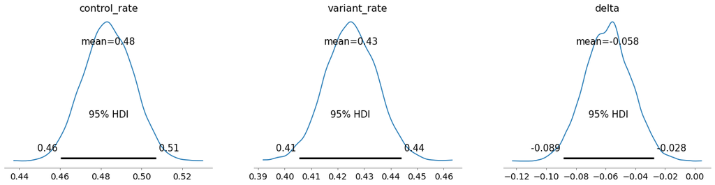

```python
# Observed data

control_clicks = df_ios_us_control['icon_shop_opens'].sum()
control_views = len(df_ios_us_control)
variant_clicks = df_ios_us_newshopicon['icon_shop_opens'].sum()
variant_views = len(df_ios_us_newshopicon)

print("control_clicks: " , control_clicks)
print("control_views: " , control_views)
print("variant_clicks: " , variant_clicks)
print("variant_views: " , variant_views)

# Define the model
with pm.Model() as model:
    # Prior distributions for the proportions
    control_rate = pm.Beta('control_rate', alpha=1, beta=1)
    variant_rate = pm.Beta('variant_rate', alpha=1, beta=1)

    # Likelihoods
    control_successes = pm.Binomial('control_successes', n=control_views, p=control_rate, observed=control_clicks)
    variant_successes = pm.Binomial('variant_successes', n=variant_views, p=variant_rate, observed=variant_clicks)

    # Difference in proportions
    delta = pm.Deterministic('delta', variant_rate - control_rate)

    # Sampling
    trace = pm.sample(2000, tune=1000)

# Summarize the posterior distribution
pm.summary(trace, hdi_prob=0.95)

# Plot the posterior distribution
pm.plot_posterior(trace, hdi_prob=0.95)

# Make a decision based on the posterior distribution
prob_delta_positive = (trace['delta'] > 0).mean()
prob_delta_negative = (trace['delta'] < 0).mean()
print("Probability of variant rate > control rate:", prob_delta_positive)
print("Probability of variant rate < control rate:", prob_delta_negative)
# Print the summary of the posterior distribution
print(pm.summary(trace, var_names=['delta']))
```

## -- Questions and Answers about the test

- For all KPIs evaluated: describe your choices in evaluating them
  - The A/B test is about the CTR of icon shop opens so for this reason I have chosen the icon_shop_opens metric
- What other data about users and their behavior would you have also liked to have to evaluate this AB test?
  - I would recommend looking at first time purchasers and first-time purchase value
- For all statistical tests performed: describe those statistical tests, their assumptions, and why they are the appropriate choice
  - I performed the proportions z-test because the size of the data is greater than 30 this means that I can perform a two-sampled z-test but another thing is the proportions z-test is specifically designed to compare proportions between two independent groups. Anyway, both z-tests can be used here and I preferred this. Also, I performed a Bayesian approach to support the result of the proportions z-test with a probabilistic method.
- What was the outcome of the experiment?
  - Outcome of the experiment is the change of shop icon is not increased our icon shop CTR.
  - Also, it's a little bit decreased the CTR of the shop in iOS.
- How confident are you in this result? Why?
  - I'm 95% confident about the test because I tested the data with 95% confidence level
- What are your recommendations for the Product as a result of this outcome?
  - I don't have enough information about the change of icon but
  - If the product changed the icon with a less animated version, please make it more animated
  - Also, you can put a bigger icon than the other icons or you can change the color of the icon.